# R Notebook

Órion Winter

Este notebook tem objetivo de mostrar a distribuição dos valores de obras na Paraíba, focando nos viéses dos dados, bem como dispersão e valores extremos. Os dados foram coletados da API do [Painel de Obras](http://paineldeobras.tce.pb.gov.br/), projeto desenvolvido pela UFCG em parceria com o TCE-PB. O conjunto de obras coletadas foram as iniciadas em 2013 até julho de 2018.

```r
library(tidyverse)
library(rjson)
library(here)
options(scipen=999)
```

```r
obrasJSON <- fromJSON(file = here("data/obras.json"))$valorObras
obrasJSON <- lapply(obrasJSON, function(x) {
  x[sapply(x, is.null)] <- NA
  as.data.frame(x)
})
obras <- do.call("rbind", obrasJSON) %>%
  rename(valor_obra = valorObra) %>%
  mutate(
    valor_obra = as.numeric(levels(valor_obra))[valor_obra],
    id = as.numeric(levels(id))[id]
  )
```

Primeiramente será mostrado a distribuição do valor de todas as obras:

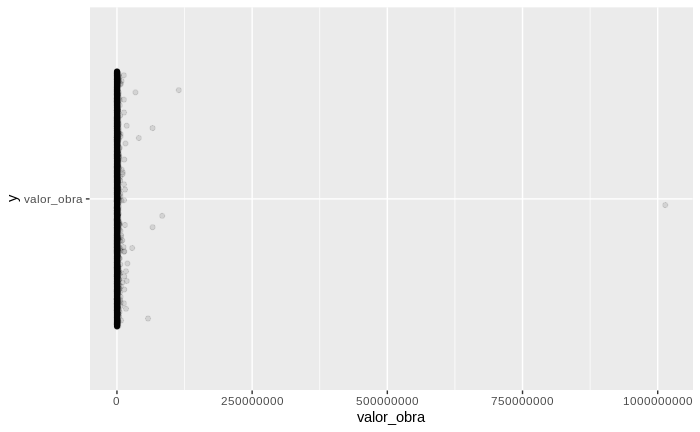

```r
obras %>%
  ggplot(aes(x = valor_obra, y = "valor_obra")) +
    geom_jitter(alpha=0.1)
```

É possível verificar que o valor das obras está bastante concentrado em valores baixos, sendo os mesmos bastante enviesados a direita, existindo apenas um valor extremo. Para uma melhor visualização dos dados, será utilizada a escala de log para atenuar valores muito altos:

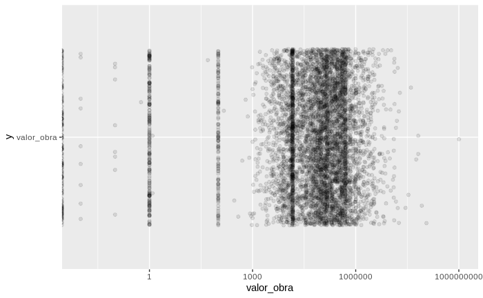

```r
obras %>%
  ggplot(aes(x = valor_obra, y = "valor_obra")) +
    geom_jitter(alpha=0.1) +
    scale_x_log10()
```

Agora é possível varificar mais facilmente a distribuição do valor das obras, onde o valor mais comum está entre 1.000 reais e 1.000.000 de reais, mas existem valores extremos como 0 reais ou 1.000.000.000 de reais.

Para comparar diferentes tipos de obras, será disposto agora os 5 tipos de obras mais construídas:

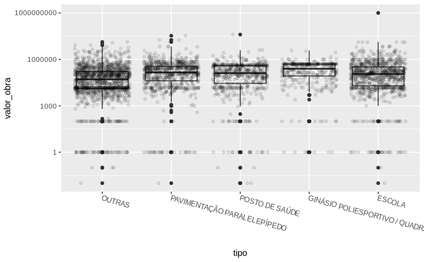

```r
obras_comuns <- obras %>%
  group_by(tipo) %>%
  summarise(contagem = n()) %>%
  top_n(5, wt = contagem)
obras %>%
  filter(valor_obra > 0, tipo %in% (obras_comuns %>% pull(tipo))) %>%
  ggplot(aes(y = valor_obra, x = tipo)) +
    geom_boxplot() +
    geom_jitter(alpha=0.1) +
    scale_y_log10() +
    theme(axis.text.x = element_text(angle = -15, hjust = 0))
```

Apesar de existir uma diferença entre o valor de diferentes tipos de obras, esse valor não parece ser muito expressivo.

Por último será mostrado o valor das obras até 10.000.000 de reais:

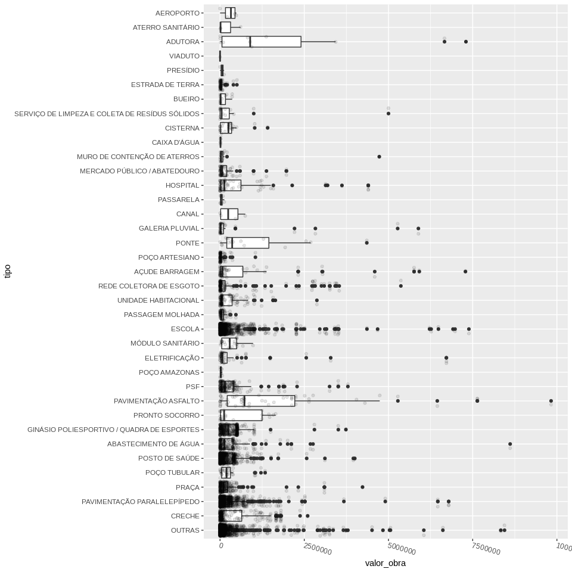

```r
obras %>%
  filter(valor_obra < 10000000) %>%
  ggplot(aes(y = valor_obra, x = tipo)) +
    geom_boxplot() +
    geom_jitter(alpha=0.1) +
    theme(axis.text.x = element_text(angle = -15, hjust = 0)) +
    coord_flip()
```

Como pode ser visto, para as obras de até R$10000000,00, tipos como pavimentação de asfalta tem uma distribuição de valores bem menos concentrada em relação a outros tipos como PSF.